# Quantitative Genetics

Genetic Models using Family Information

Felipe Ferrão and Marco Peixoto

University of Florida

**Objectives:**

**Extra information**

- [PCB 6555 – Website](https://lfelipe-ferrao.github.io/class/quantGenetic/)
- About the [author](https://lfelipe-ferrao.github.io/)
- About the [UF/IFAS Plant Breeding](https://programs.ifas.ufl.edu/plant-breeding/)

# Introduction

In the past classes, we described the importance to understand the covariance between relatives to connect statistics and genetics into the same framework. We showed that understanding the variance between families, when evaluated in an experimental design, we can make inferences about additive genetic variance. Here, we will present other examples and potential genetic models that could be used depending on the family type associated to your experiment. Our final goal is to show two potential paths using resemblance between relatives.

1. The use of genetic models using family informations, by connecting ANOVA models and genetic parameters.
2. The use of pedigree analyses in the so-called animal model or pedigree BLUP.

# Genetic Models

## Half-sib models

**Background**

- One parent is known (mother, sire, variety).
- Only additive component (Va) can be estimated.
- Parental selection (backward selection).
- Parental pedigree can (and should) be incorporated.
- Runs faster than other models (e.g. animal model).

**Drawbacks**

- Problems under non-random mating.
- Selection does not capture non-additive genetic variability.

**Model**

$$y=X\beta + Z_1b + Z_2s + e$$

- y vector of observations
- $\beta$ vector of fixed effects
- b vector of random design effects
- s vector of random sire effects (i.e.1/2 breeding value)
- e vector of random residual effects

**Genetic Parameters**

- $V_a=4\sigma^2_s$
- $V_p=\sigma^2_b + \sigma^2_s + \sigma^2$
- $h^2 = \dfrac{4\sigma^2_s }{[\sigma^2_b + \sigma^2_s + \sigma^2]}$

```r
setwd("/home/felipe/UFL Dropbox/Luis Ferrao/classes/QuantGen_24/Class7.1_FamilyModels/Dataset - Genetic models")
#--- 1. Phenotype
Dat_HalfSibModel = read.csv("./Dat_HalfSibModel.csv")
#head(Dat_HalfSibModel)


#--- 2. Transforming into factors
Dat_HalfSibModel$Ind = as.factor(Dat_HalfSibModel$Ind)
Dat_HalfSibModel$Block = as.factor(Dat_HalfSibModel$Block)
Dat_HalfSibModel$Progeny = as.factor(Dat_HalfSibModel$Progeny)
Dat_HalfSibModel$Plot = as.factor(Dat_HalfSibModel$Plot)

#--- 3. Implementing  Half sib model in ASREML
library(asreml)
HSibMod = asreml(Trait1 ~ Block,
              random = ~ Plot + Progeny,
              data = Dat_HalfSibModel)
#--- 4. Model outcomes

# variance components
summary(HSibMod)$varcomp
```

```
##          component  std.error   z.ratio bound %ch
## Progeny 0.03294678 0.01697749  1.940616     P   0
## Plot    0.06841045 0.02296399  2.979031     P   0
## units!R 0.62069284 0.03143002 19.748409     P   0
```

```r
# Heritability
vpredict(HSibMod, h2~4*V1/(V1+V2+V3)) # Narrow sense heritability
```

```
##    Estimate         SE
## h2 0.182518 0.09159263
```

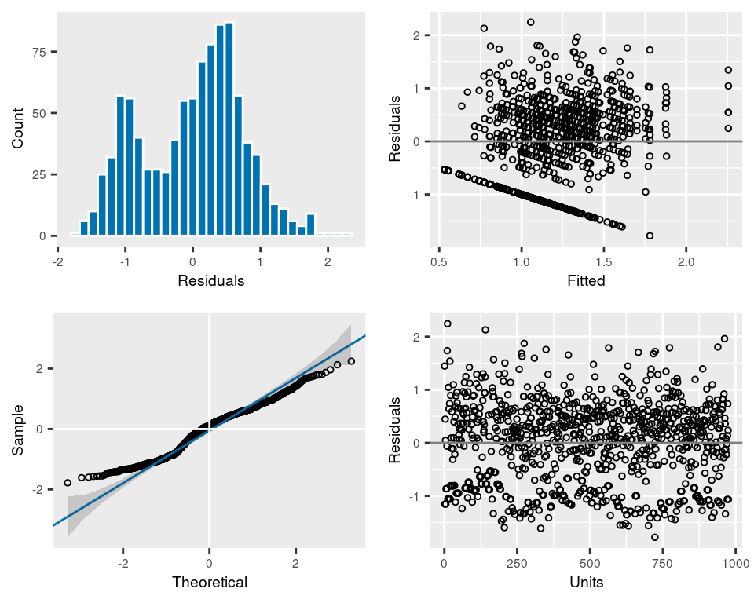

```r
# predictions
BLUP<-summary(HSibMod,coef=TRUE)$coef.random
#head(predict(HSibMod,classify='Progeny')$pvals)

# Residuals
plot(HSibMod)
```

## Full-sib models

**Background**

- Both parents are known (mother, father, family or cross).
- Mating is often planned (e.g. diallels).
- Additive and dominance component (Va and Vd) can be estimated.
- Useful for selection of parents (backward selection) or specific crosses.
- Dominance effects can be ‘captured’.
- Parental pedigree can be incorporated.

**Drawbacks**

- Dominance effects usually estimated with low precision, or confounded with other effects.
- Better results obtained with a proper planning of crosses (e.g. connected diallels).
- Need to check connectivity and number of crosses per parent (male and female) otherwise this model cannot be fitted.

**Model**

$$y=X\beta + Z_1b + Z_2m + Z_3f + Z_4mf +
e$$

- y vector of observations
- $\beta$ vector of fixed effects
- m vector of male effects(i.e.1/2 breeding value)
- f vector of female effects (i.e.1/2 breeding value)
- mf is the interaction (or family) effects
- e vector of random residual effects

**Genetic Parameters**

- $V_a=2 (\sigma^2_m + \sigma^2_f)$
- $V_d=4 (\sigma^2_{mf})$
- $V_p=\sigma^2_b + \sigma^2_m+ \sigma^2_f+ \sigma^2_{mf} + \sigma^2$
- $h^2 = \dfrac{2 (\sigma^2_m + \sigma^2_f) }{[\sigma^2_b + \sigma^2_m+ \sigma^2_f+ \sigma^2_{mf} + \sigma^2]}$
- $d^2 = \dfrac{4 (\sigma^2_{mf})}{[\sigma^2_b + \sigma^2_m+ \sigma^2_f+ \sigma^2_{mf} + \sigma^2]}$

```r
setwd("/home/felipe/UFL Dropbox/Luis Ferrao/classes/QuantGen_24/Class7.1_FamilyModels/Dataset - Genetic models")
#--- 1. Phenotype
Dat_FullSibModel = read.csv("./Dat_FullSibModel.csv")
#head(Dat_FullSibModel)


#--- 2. Transforming into factors
Dat_FullSibModel$ID = as.factor(Dat_FullSibModel$ID)
Dat_FullSibModel$Father = as.factor(Dat_FullSibModel$Father)
Dat_FullSibModel$Mother = as.factor(Dat_FullSibModel$Mother)
Dat_FullSibModel$Family = as.factor(Dat_FullSibModel$Family)
Dat_FullSibModel$Block = as.factor(Dat_FullSibModel$Block)

#str(Dat_FullSibModel)

#--- 3. Implementing  Full sib model in ASREML
FSibMod = asreml(Yield ~ Block,
              random = ~ Family + Mother + Father,
              data = Dat_FullSibModel)

#--- 4. Model outcomes

#variance components
summary(FSibMod)$varcomp
```

```
##         component  std.error   z.ratio bound %ch
## Mother  0.2142343 0.09656385  2.218577     P   0
## Father  0.2094013 0.09392969  2.229341     P   0
## Family  0.6695362 0.13656753  4.902601     P   0
## units!R 3.2089743 0.15676866 20.469489     P   0
```

```r
# Heritability
(h2<-vpredict(FSibMod,h2~2*(V1+V2)/(V1+V2+V3+V4)))
```

```
##     Estimate        SE
## h2 0.1969415 0.0575916
```

```r
(d2<-vpredict(FSibMod,fam2~4*V3/(V1+V2+V3+V4)))
```

```
##       Estimate        SE
## fam2 0.6225136 0.1208533
```

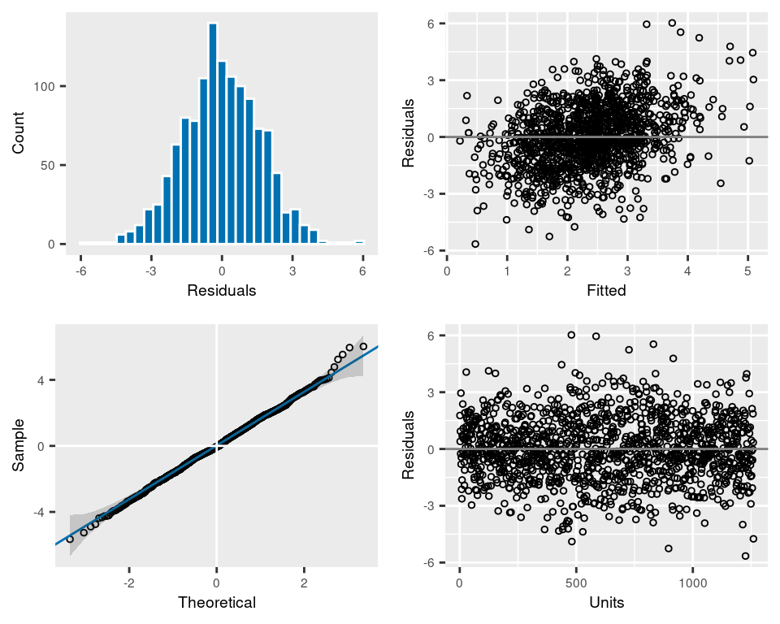

```r
# predictions
BLUP<-summary(FSibMod,coef=TRUE)$coef.random
#predict(FSibMod,classify='Father')$pvals

# Residuals
plot(FSibMod)
```

## Family Models

**Background**

- More common in animal breeding
- Occurs when parents are only present in a single cross.
- Additive and dominance component can not be separated.
- Useful for family selection or forward selection.

**Drawbacks**

- Dominance effects are confounded with additive effects.
- Potentially it could over-estimate future genetic gain.

**Model**

$$y=X\beta + Z_1b + Z_2F + e$$

- y vector of observations
- $\beta$ vector of fixed effects
- F vector of family effects (i.e.1/2 breeding value)
- e vector of random residual effects

**Genetic Parameters**

- $\sigma^2_F = V_a/2 + V_d/4$
- $V_p=\sigma^2_b + \sigma^2_F + \sigma^2$
- $h^2 = \dfrac{\sigma^2_F }{[\sigma^2_b + \sigma^2_F + \sigma^2]}$

```r
setwd("/home/felipe/UFL Dropbox/Luis Ferrao/classes/QuantGen_24/Class7.1_FamilyModels/Dataset - Genetic models")

#--- 1. Phenotype
Dat_FamilyModel = read.csv("./Dat_FamilyModel.csv")
#head(Dat_FamilyModel)

#--- 2. Transforming into factors
Dat_FamilyModel$ID = as.factor(Dat_FamilyModel$ID)
Dat_FamilyModel$Family = as.factor(Dat_FamilyModel$Family)
Dat_FamilyModel$Block = as.factor(Dat_FamilyModel$Block)

#str(Dat_FamilyModel)

#--- 3. Implementing  Half sib model in ASREML
FamMod = asreml(Yield ~ Block,
                 random = ~ Family,
                 data = Dat_FamilyModel)

#--- 4. Model outcomes

#variance components
summary(FamMod)$varcomp
```

```
##         component  std.error  z.ratio bound %ch
## Family   1.466923 0.11571651 12.67687     P   0
## units!R  2.261591 0.08103038 27.91041     P   0
```

```r
# Heritability
(hCross2<-vpredict(FamMod,hCross2~V1/(V1+V2))) #
```

```
##          Estimate         SE
## hCross2 0.3934338 0.02241936
```

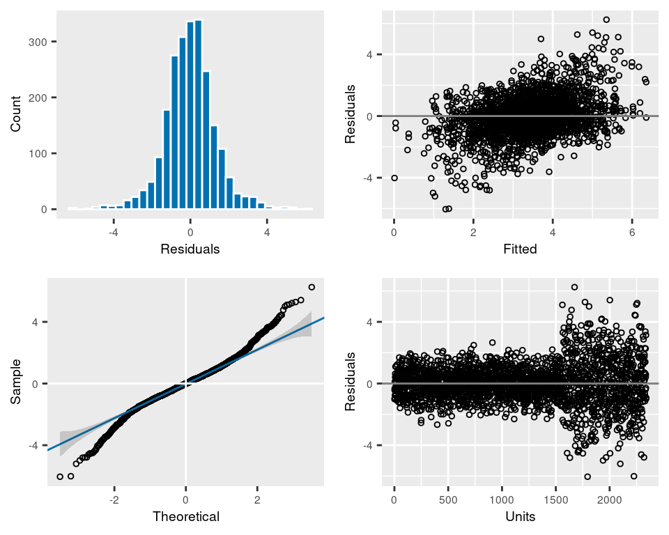

```r
# BLUPs for family
BLUP<-summary(FamMod,coef=TRUE)$coef.random
#predict(FamMod,classify='Family')$pvals

# Residuals
plot(FamMod)
```

## Clonal Models

**Background**

- It can estimated total genetic variability (Vg).
- If both parents are known (mother, father, family or cross) then the additive, dominance and epistasis components (Va, Vd and Vi) can be reasonably estimated.
- Useful for selection of parents (backward selection), crosses or specific genotypes.

**Drawbacks**

- Same difficulties as full-sib models.
- Some confounding of the epistasis component occurs (higher order terms).
- Occasionally produces negative causal variance components.

**Model**

$$y=X\beta + Z_1b + Z_2m + Z_3f + Z_4mf +
Z_5mf.c+ e$$

- y vector of observations
- $\beta$ vector of fixed effects
- m vector of male effects(i.e.1/2 breeding value)
- f vector of female effects (i.e.1/2 breeding value)
- mf is the interaction (or family) effects
- mf.c is the clonal within family effects
- e vector of random residual effects

**Genetic Parameters**

- $V_a=2 (\sigma^2_m + \sigma^2_f)$
- $V_d=4 (\sigma^2_{mf})$
- $V_i = \sigma^2_c - (\sigma^2_m + \sigma^2_f) - 3\sigma^2_{mf}$
- $V_g = V_a + V_d + V_i$
- $V_p=\sigma^2_b + \sigma^2_m+ \sigma^2_f+ \sigma^2_{mf} +\sigma^2_{c} + \sigma^2$
- $h^2 = Va/Vp$
- $d^2 = Vd/Vp$
- $H^2 = V_g/V_p$
- $i^2 = V_i/V_p$

```r
setwd("/home/felipe/UFL Dropbox/Luis Ferrao/classes/QuantGen_24/Class7.1_FamilyModels/Dataset - Genetic models")
Dat_ClonalModel = read.csv("./Dat_ClonalModel.csv")
#head(Dat_ClonalModel, 20)


#--- 2. Transforming into factors
Dat_ClonalModel$ID = as.factor(Dat_ClonalModel$ID)
Dat_ClonalModel$Family = as.factor(Dat_ClonalModel$Family)
Dat_ClonalModel$Father = as.factor(Dat_ClonalModel$Father)
Dat_ClonalModel$Mother = as.factor(Dat_ClonalModel$Mother)
Dat_ClonalModel$CloneID = as.factor(Dat_ClonalModel$CloneID)
Dat_ClonalModel$Rept = as.factor(Dat_ClonalModel$Rept)

#str(Dat_ClonalModel)

#--- 3. Implementing  Half sib model in ASREML
# Simple Clonal Model
clonalMod1 = asreml(Yield ~ Rept,
                 random = ~ CloneID,
                 data = Dat_ClonalModel)

summary(clonalMod1)$varcomp
```

```
##         component std.error  z.ratio bound %ch
## CloneID  323.8572  10.60271 30.54475     P   0
## units!R 1082.5457  11.10727 97.46280     P   0
```

```r
(H2<-vpredict(clonalMod1,H2~V1/(V1+V2)))
```

```
##     Estimate         SE
## H2 0.2302734 0.00665966
```

```r
# Full Clonal Model
clonalMod2 = asreml(Yield ~ Rept,
                    random = ~ CloneID + Family + Mother + Father,
                    data = Dat_ClonalModel)

summary(clonalMod2)$varcomp
```

```
##          component std.error   z.ratio bound %ch
## Mother    70.69294 27.054373  2.612995     P   0
## Father    36.66294 15.663242  2.340700     P   0
## Family    51.26007  7.151379  7.167858     P   0
## CloneID  192.57718  8.916493 21.597862     P   0
## units!R 1082.54547 11.107267 97.462813     P   0
```

```r
(H2<-vpredict(clonalMod2,H2~((2*(V1+V2))+(4*V3)+(V4-(V1+V2)-3*V3))/(V1+V2+V3+V4+V5))) # Broad sense heritability
```

```
##     Estimate         SE
## H2 0.2449492 0.01765477
```

```r
(h2<-vpredict(clonalMod2,h2~2*(V1+V2)/(V1+V2+V3+V4+V5))) # narrow sense heritability
```

```
##     Estimate         SE
## h2 0.1497566 0.04077411
```

```r
(d2<-vpredict(clonalMod2,d2~4*V3/(V1+V2+V3+V4+V5))) # dominance coefficient
```

```
##     Estimate         SE
## d2 0.1430109 0.01980121
```

```r
(i2<-vpredict(clonalMod2,i2~(V4-(V1+V2)-3*V3)/(V1+V2+V3+V4+V5))) # clonal coefficient
```

```
##       Estimate         SE
## i2 -0.04781827 0.02545569
```

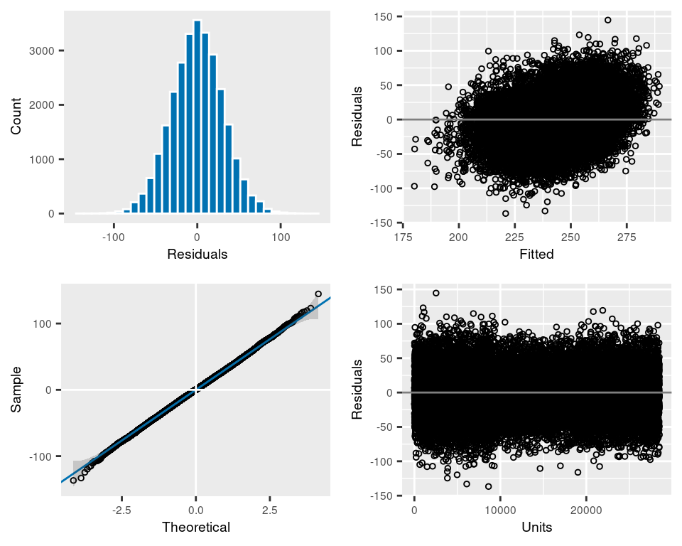

```r
# BLUPs for family
BLUP<-summary(clonalMod2,coef=TRUE)$coef.random
#predict(clonalMod2,classify='Father')$pvals

# Residuals
plot(clonalMod2)
```

# Conclusion

We presented four classes of genetic models that use family information to compute genetic parameters. Next classes the idea is to present the animal model and pedigree information